# 04 · Set classification

## Load packages

`pROC` and `enrichVolcano` (not on CRAN) are called with `::`.

```r
pacman::p_load(here, dplyr, tidyr, purrr, stringr, ggplot2, readxl, writexl)
here::i_am("03_Pathway_Enrichment/04_set_classification/a_script/04_set_classification.qmd")
```

## Read inputs

Classification asks whether a set’s score separates two groups of samples, a question the contrast tests of `01_` do not ask directly.

```r
stage <- here("03_Pathway_Enrichment", "04_set_classification")
set_catalog <- read_excel(
  here("03_Pathway_Enrichment", "00_build_gene_sets", "c_data", "00_build_gene_sets.xlsx"),
  "set_catalog"
)
set_score <- readRDS(here("03_Pathway_Enrichment", "03_run_singscore", "c_data", "set_scores.rds"))
targets <- readRDS(here("01_Preprocess", "02_Quantification", "c_data", "proteins.rds"))$targets
catalog <- set_catalog |>
  filter(qualifies) |>
  select(set_id, database, pathway)
values <- set_score[catalog$set_id, ]
table(catalog$database)
```

```
    GO_Slim        GOBP    Hallmark KEGG_Legacy    Reactome
         59        1366          41          94         430
```

## Pair the samples

Every comparison is paired, so participant traits cancel. Treatment comes from the targets, never the leg letter: leg assignment was counterbalanced.

```r
by_timepoint <- targets |>
  mutate(leg_id = paste(participant, leg, sep = "_")) |>
  select(leg_id, participant, leg, treatment, timepoint, sample_id) |>
  pivot_wider(names_from = timepoint, values_from = sample_id)
legs <- drop_na(by_timepoint, T1, T2) |> arrange(participant, treatment)
```

```r
# Participants without both legs drop out.
pair_by_treatment <- function(data, column) {
  data |>
    select(participant, treatment, value = all_of(column)) |>
    pivot_wider(names_from = treatment, values_from = value) |>
    drop_na(BFR, HLRT)
}
baseline <- pair_by_treatment(by_timepoint, "T1")
post <- pair_by_treatment(by_timepoint, "T2")
delta_pairs <- pair_by_treatment(legs, "leg_id")
c(legs = nrow(legs), baseline = nrow(baseline), post = nrow(post), change = nrow(delta_pairs))
```

```
    legs baseline     post   change
      65       33       32       32
```

```r
delta <- values[, legs$T2] - values[, legs$T1]
colnames(delta) <- legs$leg_id
```

## Define the tasks

Five tasks: pre against post in each arm, and BFR against HLRT at baseline, after training and in change. Baseline precedes training, so it shows what the method returns when nothing is there.

```r
# positive and negative are paired by position; favours is the group an AUC above 0.5 points to.
arm <- split(legs, legs$treatment)
tasks <- list(
  pre_vs_post_BFR = list(
    values = values, positive = arm$BFR$T2, negative = arm$BFR$T1,
    label = "Pre to post, BFR", favours = "post", unit = "legs"
  ),
  pre_vs_post_HLRT = list(
    values = values, positive = arm$HLRT$T2, negative = arm$HLRT$T1,
    label = "Pre to post, HLRT", favours = "post", unit = "legs"
  ),
  baseline_BFR_vs_HLRT = list(
    values = values, positive = baseline$BFR, negative = baseline$HLRT,
    label = "Baseline BFR vs HLRT", favours = "BFR", unit = "participants"
  ),
  post_BFR_vs_HLRT = list(
    values = values, positive = post$BFR, negative = post$HLRT,
    label = "Post BFR vs HLRT", favours = "BFR", unit = "participants"
  ),
  delta_BFR_vs_HLRT = list(
    values = delta, positive = delta_pairs$BFR, negative = delta_pairs$HLRT,
    label = "Change, BFR vs HLRT", favours = "BFR", unit = "participants"
  )
)
tibble(
  task = names(tasks), label = map_chr(tasks, "label"),
  pairs = map_int(tasks, function(spec) length(spec$positive)), favours = map_chr(tasks, "favours")
)
```

```
# A tibble: 5 × 4
  task                 label                pairs favours
  <chr>                <chr>                <int> <chr>
1 pre_vs_post_BFR      Pre to post, BFR        32 post
2 pre_vs_post_HLRT     Pre to post, HLRT       33 post
3 baseline_BFR_vs_HLRT Baseline BFR vs HLRT    33 BFR
4 post_BFR_vs_HLRT     Post BFR vs HLRT        32 BFR
5 delta_BFR_vs_HLRT    Change, BFR vs HLRT     32 BFR
```

## Score each set

The AUC reads as the chance a random positive sample outscores a random negative one, but ignores the pairing, so p comes from the paired Wilcoxon signed-rank test. BH runs within each task and collection.

```r
# pROC::roc() auto-orients, turning an AUC of 0.194 into 0.806; direction = "<" pins it.
fit_roc <- function(score, spec) {
  pROC::roc(
    controls = score[spec$negative], cases = score[spec$positive],
    direction = "<", quiet = TRUE
  )
}
# Named `spec`, not `task`: tibble() would shadow it with the `task` column it builds first.
set_auc <- imap(tasks, function(spec, name) {
  tibble(
    task = name, task_label = spec$label, set_id = rownames(spec$values),
    n_pairs = length(spec$positive),
    auc = apply(spec$values, 1, function(row) as.numeric(pROC::auc(fit_roc(row, spec)))),
    p_paired = apply(spec$values, 1, function(row) {
      wilcox.test(row[spec$positive], row[spec$negative], paired = TRUE)$p.value
    })
  )
}) |>
  list_rbind() |>
  left_join(select(catalog, set_id, database, pathway), by = "set_id") |>
  mutate(fdr = p.adjust(p_paired, "BH"), .by = c(task, database))
```

## Compare with chance

Sets co-vary, so a nominal count means little alone; its ratio to 5% of the sets tested reads 1 at chance, with one denominator per collection.

```r
# The ratio divides by the unrounded expectation, not the rounded `expected` column.
chance_expectation <- set_auc |>
  transmute(
    analysis = "classification", comparison = task_label, database, n_pairs, p = p_paired, fdr
  ) |>
  summarise(
    features = n(), nominal = sum(p < 0.05), expected = round(n() * 0.05, 1),
    ratio = round(nominal / (n() * 0.05), 2), fdr_sig = sum(fdr < 0.05),
    .by = c(analysis, comparison, database, n_pairs)
  )
```

```r
chance_expectation |>
  select(comparison, database, ratio) |>
  pivot_wider(names_from = database, values_from = ratio)
```

```
# A tibble: 5 × 6
  comparison           Hallmark Reactome KEGG_Legacy  GOBP GO_Slim
  <chr>                   <dbl>    <dbl>       <dbl> <dbl>   <dbl>
1 Pre to post, BFR         2.44     3.72        3.4   4.07    7.46
2 Pre to post, HLRT        4.39     5.21        4.47  4.1     4.75
3 Baseline BFR vs HLRT     1.46     0.51        1.06  1.26    0.68
4 Post BFR vs HLRT         0.98     0.33        0.85  1.04    0.68
5 Change, BFR vs HLRT      1.95     0.28        0.64  0.82    1.69
```

```r
summarise(chance_expectation, fdr_sig = sum(fdr_sig), .by = comparison)
```

```
# A tibble: 5 × 2
  comparison           fdr_sig
  <chr>                  <int>
1 Pre to post, BFR          30
2 Pre to post, HLRT        112
3 Baseline BFR vs HLRT       0
4 Post BFR vs HLRT           0
5 Change, BFR vs HLRT        1
```

## Draw figures

Every set reaching nominal p gets an ROC panel, so the reader sees how weak most separations are.

```r
figure_theme <- theme_minimal(base_size = 9) +
  theme(
    strip.text = element_text(size = 6.8, lineheight = 1.2, margin = margin(3, 3, 4, 3)),
    panel.grid.minor = element_blank(),
    panel.spacing = unit(4, "mm"),
    legend.position = "top"
  )
```

```r
# Pages are built from their own rows: a paginating facet would build every panel for every page.
roc_figure <- function(task_name, number, db) {
  spec <- tasks[[task_name]]
  hits <- set_auc |>
    filter(task == task_name, database == db, p_paired < 0.05) |>
    arrange(p_paired)
  if (nrow(hits) == 0) {
    return(list())
  }
  curves <- pmap(hits, function(set_id, database, pathway, auc, p_paired, fdr, ...) {
    coordinates <- pROC::coords(fit_roc(spec$values[set_id, ], spec), "all")
    tibble(
      fpr = 1 - coordinates$specificity, tpr = coordinates$sensitivity,
      direction = if_else(auc >= 0.5, "higher", "lower"),
      panel = sprintf(
        "%s\nAUC %.2f   p %s   q %s",
        str_wrap(paste0(database, ": ", enrichVolcano::clean_label(pathway, width = 1000)), 40),
        auc, signif(p_paired, 2), signif(fdr, 2)
      )
    )
  }) |>
    list_rbind() |>
    mutate(panel = factor(panel, levels = unique(panel))) |>
    arrange(panel, fpr, tpr)
  pages <- split(curves, (as.integer(curves$panel) - 1) %/% 12)
  imap(unname(pages), function(page, i) {
    page_note <- if (length(pages) > 1) sprintf(" (page %d of %d)", i, length(pages)) else ""
    ggplot(droplevels(page), aes(fpr, tpr, colour = direction, fill = direction)) +
      geom_abline(linetype = "22", linewidth = 0.35, colour = "grey60") +
      geom_ribbon(aes(ymin = 0, ymax = tpr), alpha = 0.16, colour = NA) +
      geom_step(linewidth = 0.7, direction = "hv") +
      facet_wrap(~panel, ncol = 3, nrow = 4) +
      scale_colour_manual(
        values = c(higher = "#B2182B", lower = "#2166AC"), aesthetics = c("colour", "fill"),
        guide = "none"
      ) +
      coord_equal(xlim = c(0, 1), ylim = c(0, 1), expand = FALSE) +
      scale_x_continuous(breaks = c(0, 0.5, 1)) +
      scale_y_continuous(breaks = c(0, 0.5, 1)) +
      labs(
        x = "1 - specificity", y = "sensitivity",
        title = sprintf("S%d. ROC curves, %s, %s%s", number, spec$label, db, page_note)
      ) +
      figure_theme
  })
}
```

S10 draws each chance ratio as a bar, one panel per task.

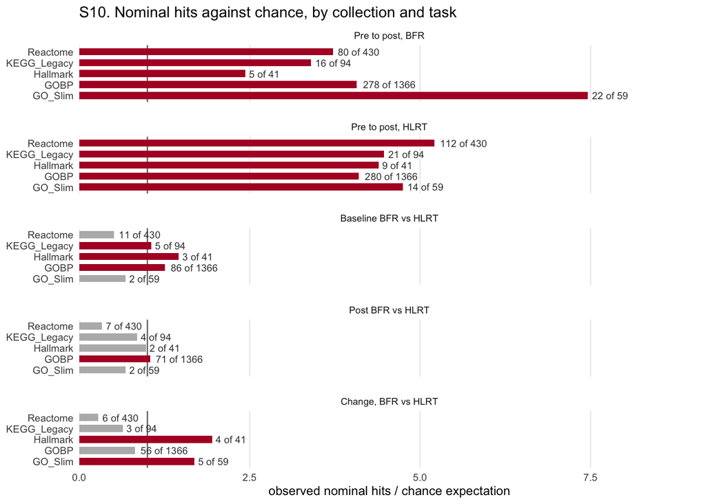

```r
chance_plot <- chance_expectation |>
  mutate(comparison = factor(comparison, map_chr(tasks, "label"))) |>
  ggplot(aes(ratio, database, fill = ratio > 1)) +
  geom_vline(xintercept = 1, linewidth = 0.4, colour = "grey40") +
  geom_col(width = 0.65) +
  geom_text(
    aes(label = sprintf("%d of %d", nominal, features)),
    hjust = -0.12, size = 2.5, colour = "grey25"
  ) +
  facet_wrap(vars(comparison), ncol = 1) +
  scale_fill_manual(values = c(`TRUE` = "#B2182B", `FALSE` = "grey72"), guide = "none") +
  scale_x_continuous(expand = expansion(mult = c(0, 0.22))) +
  labs(
    x = "observed nominal hits / chance expectation", y = NULL,
    title = "S10. Nominal hits against chance, by collection and task"
  ) +
  figure_theme +
  theme(panel.grid.major.y = element_blank())
chance_plot
```

One PDF: S10 first, then S6 to S9 per collection. Baseline is in the chance figure only.

```r
drawn_tasks <- setdiff(names(tasks), "baseline_BFR_vs_HLRT")
collection_order <- c("Hallmark", "GO_Slim", "KEGG_Legacy", "Reactome", "GOBP")
stopifnot(setequal(collection_order, catalog$database))
pdf(file.path(stage, "b_reports", "04_set_classification.pdf"), width = 8.27, height = 11.69)
print(chance_plot)
for (db in collection_order) {
  for (i in seq_along(drawn_tasks)) walk(roc_figure(drawn_tasks[i], 5 + i, db), print)
}
invisible(dev.off())
```

## Save results

```r
write_xlsx(
  list(
    chance_expectation = chance_expectation,
    set_auc = arrange(set_auc, p_paired)
  ),
  file.path(stage, "c_data", "04_set_classification.xlsx")
)
```